# Unzip the data

```python
!unzip -q traffic_signs.zip
```

# Installing and importing libraries

```python
!pip install ultralytics
```

```
Downloading ultralytics-8.3.248-py3-none-any.whl (1.2 MB)
   ━━━━━━━━━━━━━━━━━━━━━━━━━━━━━━━━━━━━━━━━ 1.2/1.2 MB 75.5 MB/s eta 0:00:00
Downloading ultralytics_thop-2.0.18-py3-none-any.whl (28 kB)
```

```python
import os
import random
import pandas as pd
from PIL import Image
import cv2
from ultralytics import YOLO
from IPython.display import Video
import numpy as np
import matplotlib.pyplot as plt
import seaborn as sns
sns.set(style='darkgrid')
import pathlib
import glob
from tqdm.notebook import trange, tqdm
import warnings
warnings.filterwarnings('ignore')
```

```
Creating new Ultralytics Settings v0.0.6 file ✅
View Ultralytics Settings with 'yolo settings' or at '/root/.config/Ultralytics/settings.json'
Update Settings with 'yolo settings key=value', i.e. 'yolo settings runs_dir=path/to/dir'. For help see https://docs.ultralytics.com/quickstart/#ultralytics-settings.
```

```python
sns.set(rc={'axes.facecolor': '#eae8fa'}, style='darkgrid')
```

# Exploratory Data Analysis (EDA)

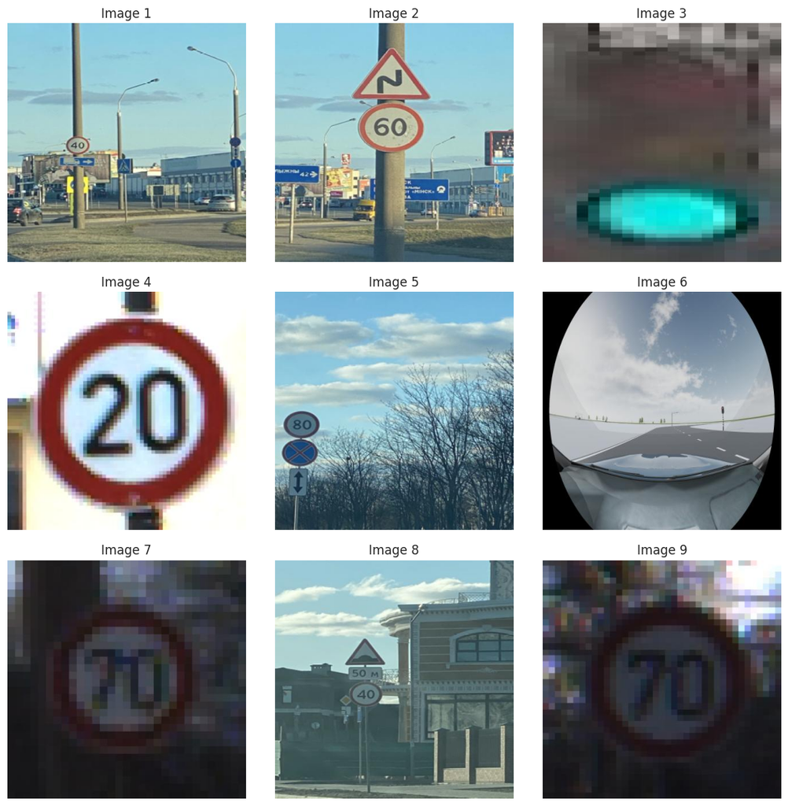

```python
Image_dir = 'car/train/images'

num_samples = 9
image_files = os.listdir(Image_dir)

# Randomly select num_samples images
rand_images = random.sample(image_files, num_samples)

fig, axes = plt.subplots(3, 3, figsize=(11, 11))

for i in range(num_samples):
    image = rand_images[i]
    ax = axes[i // 3, i % 3]
    ax.imshow(plt.imread(os.path.join(Image_dir, image)))
    ax.set_title(f'Image {i+1}')
    ax.axis('off')

plt.tight_layout()
plt.show()
```

```python
# Get the size of the image
image = cv2.imread("car/train/images/00000_00000_00012_png.rf.23f94508dba03ef2f8bd187da2ec9c26.jpg")
h, w, c = image.shape
print(f"The image has dimensions {w}x{h} and {c} channels.")
```

```
The image has dimensions 416x416 and 3 channels.
```

# Try pre-trained YOLOv8

```
Downloading https://github.com/ultralytics/assets/releases/download/v8.3.0/yolov8n.pt to 'yolov8n.pt': 100% ━━━━━━━━━━━━ 6.2MB 327.6MB/s 0.0s

image 1/1 /content/car/train/images/FisheyeCamera_1_00228_png.rf.e7c43ee9b922f7b2327b8a00ccf46a4c.jpg: 640x640 (no detections), 7.9ms
Speed: 13.8ms preprocess, 7.9ms inference, 4.6ms postprocess per image at shape (1, 3, 640, 640)
```

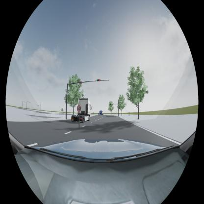

```python
# Use a pretrained YOLOv8n model
model = YOLO("yolov8n.pt")

# Use the model to detect object
image = "car/train/images/FisheyeCamera_1_00228_png.rf.e7c43ee9b922f7b2327b8a00ccf46a4c.jpg"
result_predict = model.predict(source = image, imgsz=(640))

# show results
plot = result_predict[0].plot()
plot = cv2.cvtColor(plot, cv2.COLOR_BGR2RGB)
display(Image.fromarray(plot))
```

# YOLOv8 based traffic signs detection model

- Training step

```python
!pip install --upgrade ultralytics ray
```

```
Downloading ray-2.53.0-cp312-cp312-manylinux2014_x86_64.whl (72.4 MB)
   ━━━━━━━━━━━━━━━━━━━━━━━━━━━━━━━━━━━━━━━━ 72.4/72.4 MB 13.6 MB/s eta 0:00:00
```

```python
# Build from YAML and transfer weights
Final_model = YOLO('yolov8n.pt')

# Training The Final Model
Result_Final_model = Final_model.train(data="car/data.yaml",epochs = 30, batch = -1, optimizer = 'auto')
```

```
Ultralytics 8.3.248 🚀 Python-3.12.12 torch-2.9.0+cu126 CUDA:0 (Tesla T4, 15095MiB)
engine/trainer: agnostic_nms=False, amp=True, augment=False, auto_augment=randaugment, batch=-1, bgr=0.0, box=7.5, cache=False, cfg=None, classes=None, close_mosaic=10, cls=0.5, compile=False, conf=None, copy_paste=0.0, copy_paste_mode=flip, cos_lr=False, cutmix=0.0, data=car/data.yaml, degrees=0.0,…
Downloading https://ultralytics.com/assets/Arial.ttf to '/root/.config/Ultralytics/Arial.ttf': 100% ━━━━━━━━━━━━ 755.1KB 52.8MB/s 0.0s
Overriding model.yaml nc=80 with nc=15

                   from  n    params  module                                       arguments
  0                  -1  1       464  ultralytics.nn.modules.conv.Conv             [3, 16, 3, 2]
  1                  -1  1      4672  ultralytics.nn.modules.conv.Conv             [16, 32, 3, 2]
  2                  -1  1      7360  ultralytics.nn.modules.block.C2f             [32, 32, 1, True]
  3                  -1  1     18560  ultralytics.nn.modules.conv.Conv             [32, 64, 3, 2]
  4                  -1  2     49664  ultralytics.nn.modules.block.C2f             [64, 64, 2, True]
  5                  -1  1     73984  ultralytics.nn.modules.conv.Conv             [64, 128, 3, 2]
  6                  -1  2    197632  ultralytics.nn.modules.block.C2f             [128, 128, 2, True]
  7                  -1  1    295424  ultralytics.nn.modules.conv.Conv             [128, 256, 3, 2]
  8                  -1  1    460288  ultralytics.nn.modules.block.C2f             [256, 256, 1, True]
  9                  -1  1    164608  ultralytics.nn.modules.block.SPPF            [256, 256, 5]
 10                  -1  1         0  torch.nn.modules.upsampling.Upsample         [None, 2, 'nearest']
 11             [-1, 6]  1         0  ultralytics.nn.modules.conv.Concat           [1]
 12                  -1  1    148224  ultralytics.nn.modules.block.C2f             [384, 128, 1]
 13                  -1  1         0  torch.nn.modules.upsampling.Upsample         [None, 2, 'nearest']
 14             [-1, 4]  1         0  ultralytics.nn.modules.conv.Concat           [1]
 15                  -1  1     37248  ultralytics.nn.modules.block.C2f             [192, 64, 1]
 16                  -1  1     36992  ultralytics.nn.modules.conv.Conv             [64, 64, 3, 2]
 17            [-1, 12]  1         0  ultralytics.nn.modules.conv.Concat           [1]
 18                  -1  1    123648  ultralytics.nn.modules.block.C2f             [192, 128, 1]
 19                  -1  1    147712  ultralytics.nn.modules.conv.Conv             [128, 128, 3, 2]
 20             [-1, 9]  1         0  ultralytics.nn.modules.conv.Concat           [1]
 21                  -1  1    493056  ultralytics.nn.modules.block.C2f             [384, 256, 1]
 22        [15, 18, 21]  1    754237  ultralytics.nn.modules.head.Detect           [15, [64, 128, 256]]
Model summary: 129 layers, 3,013,773 parameters, 3,013,757 gradients, 8.2 GFLOPs

Transferred 319/355 items from pretrained weights
Freezing layer 'model.22.dfl.conv.weight'
AMP: running Automatic Mixed Precision (AMP) checks...
Downloading https://github.com/ultralytics/assets/releases/download/v8.3.0/yolo11n.pt to 'yolo11n.pt': 100% ━━━━━━━━━━━━ 5.4MB 65.8MB/s 0.1s
AMP: checks passed ✅
train: Fast image access ✅ (ping: 0.0±0.0 ms, read: 1038.6±384.2 MB/s, size: 24.1 KB)
train: Scanning /content/car/train/labels... 3530 images, 3 backgrounds, 0 corrupt: 100% ━━━━━━━━━━━━ 3530/3530 2.3Kit/s 1.5s
train: New cache created: /content/car/train/labels.cache
albumentations: Blur(p=0.01, blur_limit=(3, 7)), MedianBlur(p=0.01, blur_limit=(3, 7)), ToGray(p=0.01, method='weighted_average', num_output_channels=3), CLAHE(p=0.01, clip_limit=(1.0, 4.0), tile_grid_size=(8, 8))
```

[output cut: 185 more lines]

```
             Red Light         74        108      0.912      0.671      0.831      0.499
       Speed Limit 100         52         52      0.957      0.942      0.987      0.874
       Speed Limit 110         17         17      0.761      0.882      0.952      0.872
       Speed Limit 120         60         60          1       0.92      0.994       0.92
        Speed Limit 20         56         56      0.987      0.982      0.986      0.862
        Speed Limit 30         71         74      0.993      0.959      0.987      0.931
        Speed Limit 40         53         55      0.952      0.945      0.989      0.882
        Speed Limit 50         68         71          1      0.847      0.975      0.874
        Speed Limit 60         76         76      0.987      0.908      0.966      0.887
        Speed Limit 70         78         78      0.978      0.962      0.988      0.893
        Speed Limit 80         56         56          1      0.871      0.986      0.873
        Speed Limit 90         38         38      0.969      0.842      0.971      0.804
                  Stop         81         81      0.974      0.988      0.992      0.915
Speed: 0.2ms preprocess, 2.4ms inference, 0.0ms loss, 7.3ms postprocess per image
Results saved to /content/runs/detect/train
```

- Validation step

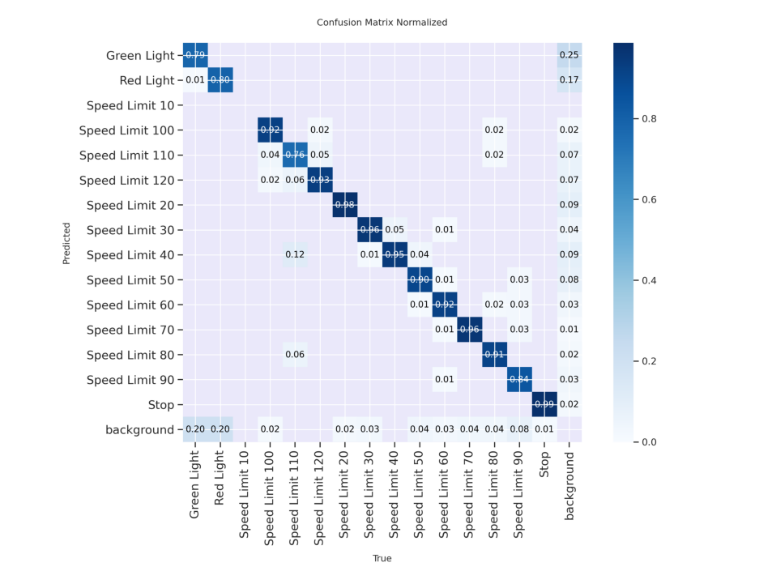

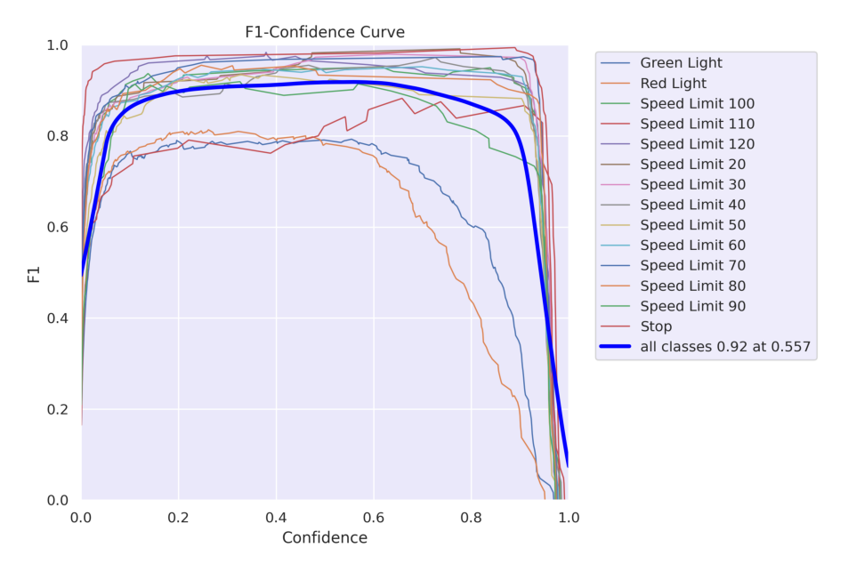

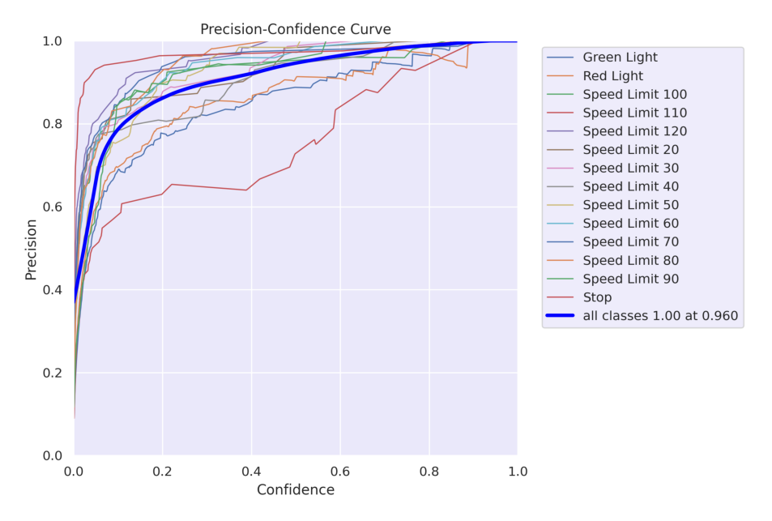

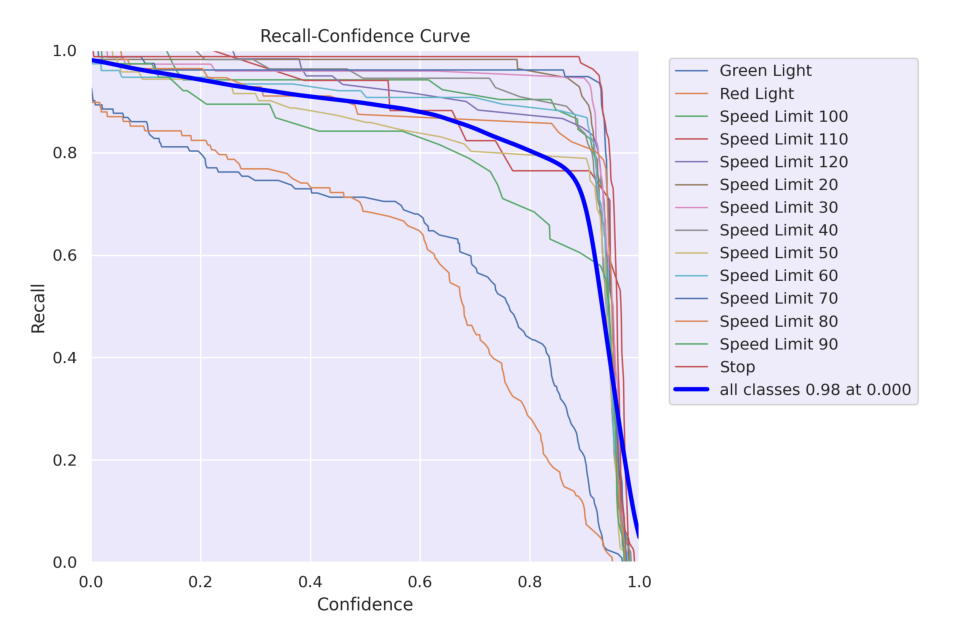

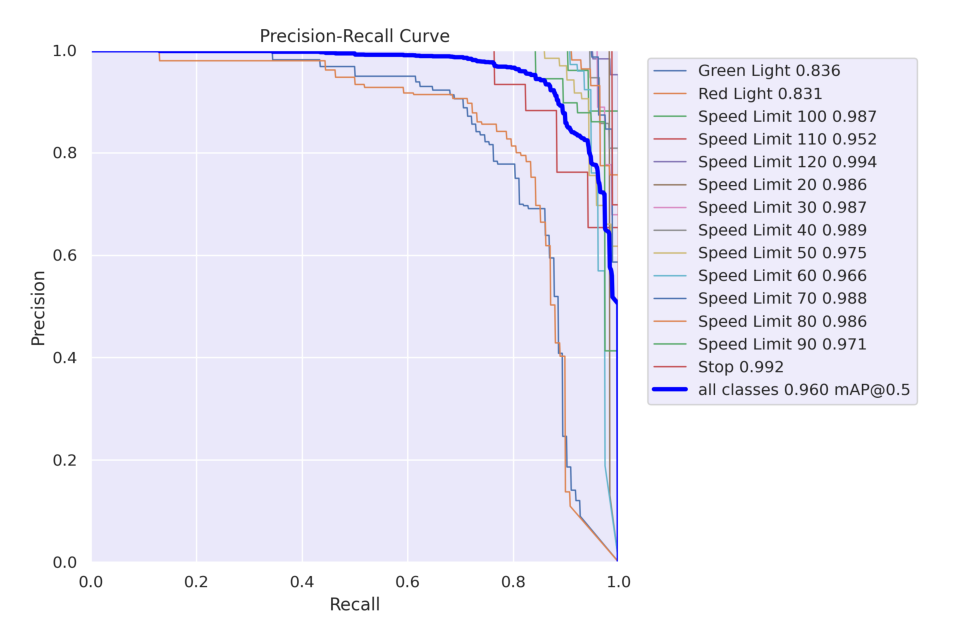

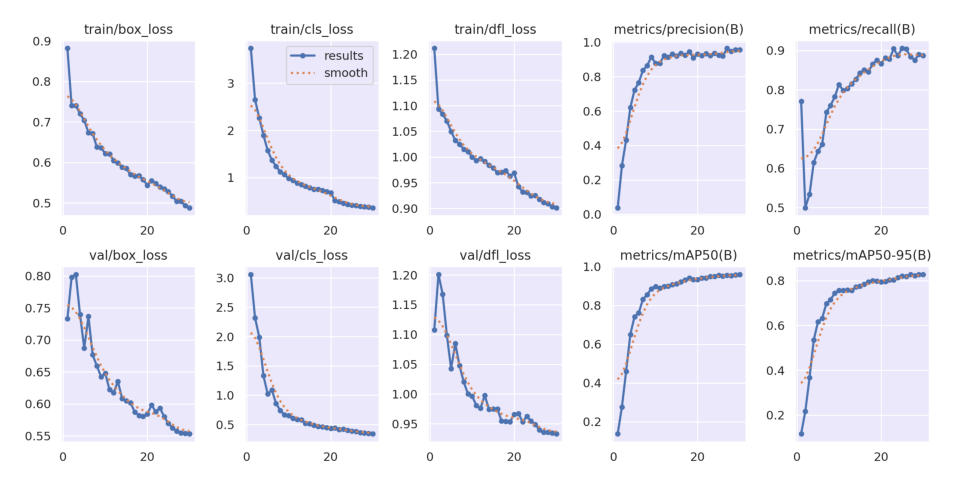

```python
import os
import cv2
import matplotlib.pyplot as plt

def display_images(post_training_files_path, image_files):

    for image_file in image_files:
        image_path = os.path.join(post_training_files_path, image_file)
        img = cv2.imread(image_path)
        img = cv2.cvtColor(img, cv2.COLOR_BGR2RGB)

        plt.figure(figsize=(10, 10), dpi=120)
        plt.imshow(img)
        plt.axis('off')
        plt.show()

# List of image files to display
image_files = [
    'confusion_matrix_normalized.png',
    'BoxF1_curve.png',
    'BoxP_curve.png',
    'BoxR_curve.png',
    'BoxPR_curve.png',
    'results.png'
]

# Path to the directory containing the images
post_training_files_path = 'runs/detect/train'

# Display the images
display_images(post_training_files_path, image_files)
```

```python
Result_Final_model = pd.read_csv('runs/detect/train/results.csv')
Result_Final_model.tail(10)
```

|  | epoch | time | train/box_loss | train/cls_loss | train/dfl_loss | metrics/precision(B) | metrics/recall(B) | metrics/mAP50(B) | metrics/mAP50-95(B) | val/box_loss | val/cls_loss | val/dfl_loss | lr/pg0 | lr/pg1 | lr/pg2 |
| --- | --- | --- | --- | --- | --- | --- | --- | --- | --- | --- | --- | --- | --- | --- | --- |
| 20 | 21 | 1325.89 | 0.55514 | 0.51236 | 0.94222 | 0.92231 | 0.88139 | 0.94216 | 0.79666 | 0.59815 | 0.44285 | 0.96737 | 0.000179 | 0.000179 | 0.000179 |
| 21 | 22 | 1385.07 | 0.54780 | 0.49077 | 0.93199 | 0.93354 | 0.87770 | 0.94226 | 0.80392 | 0.58781 | 0.41794 | 0.95328 | 0.000161 | 0.000161 | 0.000161 |
| 22 | 23 | 1443.63 | 0.53989 | 0.45799 | 0.93142 | 0.92321 | 0.90439 | 0.95020 | 0.80315 | 0.59358 | 0.42070 | 0.96243 | 0.000144 | 0.000144 | 0.000144 |
| 23 | 24 | 1503.59 | 0.53490 | 0.43730 | 0.92417 | 0.93665 | 0.88708 | 0.95001 | 0.81295 | 0.58018 | 0.40366 | 0.95462 | 0.000127 | 0.000127 | 0.000127 |
| 24 | 25 | 1564.96 | 0.52842 | 0.41991 | 0.92537 | 0.92347 | 0.90559 | 0.95621 | 0.82043 | 0.56936 | 0.38612 | 0.94907 | 0.000109 | 0.000109 | 0.000109 |
| 25 | 26 | 1626.78 | 0.51676 | 0.40749 | 0.91780 | 0.91909 | 0.90353 | 0.95070 | 0.81905 | 0.56236 | 0.38142 | 0.93949 | 0.000092 | 0.000092 | 0.000092 |
| 26 | 27 | 1687.99 | 0.50409 | 0.39320 | 0.91191 | 0.96447 | 0.88397 | 0.95621 | 0.82733 | 0.55723 | 0.36195 | 0.93601 | 0.000075 | 0.000075 | 0.000075 |
| 27 | 28 | 1748.23 | 0.50394 | 0.38592 | 0.90912 | 0.94588 | 0.87563 | 0.95304 | 0.82189 | 0.55437 | 0.35849 | 0.93604 | 0.000057 | 0.000057 | 0.000057 |
| 28 | 29 | 1808.03 | 0.49342 | 0.37543 | 0.90331 | 0.95584 | 0.89030 | 0.95744 | 0.82685 | 0.55413 | 0.34661 | 0.93421 | 0.000040 | 0.000040 | 0.000040 |
| 29 | 30 | 1867.23 | 0.48843 | 0.36354 | 0.90136 | 0.95584 | 0.88727 | 0.96006 | 0.82794 | 0.55325 | 0.34217 | 0.93318 | 0.000023 | 0.000023 | 0.000023 |

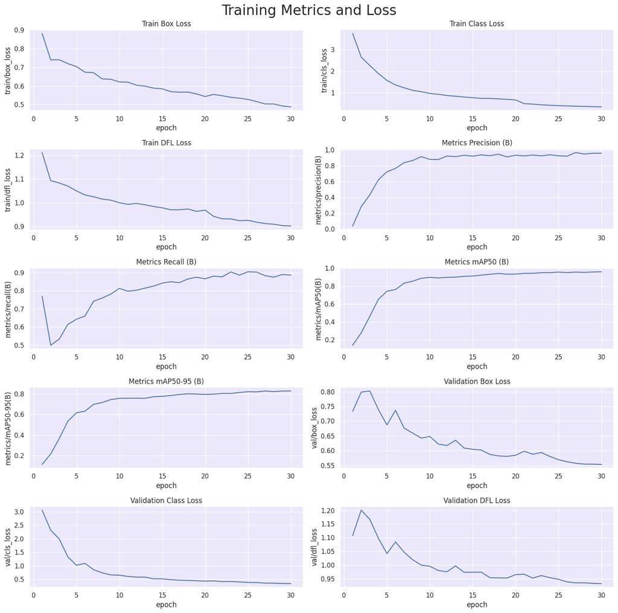

```python
# Read the results.csv file as a pandas dataframe
Result_Final_model.columns = Result_Final_model.columns.str.strip()

# Create subplots
fig, axs = plt.subplots(nrows=5, ncols=2, figsize=(15, 15))

# Plot the columns using seaborn
sns.lineplot(x='epoch', y='train/box_loss', data=Result_Final_model, ax=axs[0,0])
sns.lineplot(x='epoch', y='train/cls_loss', data=Result_Final_model, ax=axs[0,1])
sns.lineplot(x='epoch', y='train/dfl_loss', data=Result_Final_model, ax=axs[1,0])
sns.lineplot(x='epoch', y='metrics/precision(B)', data=Result_Final_model, ax=axs[1,1])
sns.lineplot(x='epoch', y='metrics/recall(B)', data=Result_Final_model, ax=axs[2,0])
sns.lineplot(x='epoch', y='metrics/mAP50(B)', data=Result_Final_model, ax=axs[2,1])
sns.lineplot(x='epoch', y='metrics/mAP50-95(B)', data=Result_Final_model, ax=axs[3,0])
sns.lineplot(x='epoch', y='val/box_loss', data=Result_Final_model, ax=axs[3,1])
sns.lineplot(x='epoch', y='val/cls_loss', data=Result_Final_model, ax=axs[4,0])
sns.lineplot(x='epoch', y='val/dfl_loss', data=Result_Final_model, ax=axs[4,1])

# Set titles and axis labels for each subplot
axs[0,0].set(title='Train Box Loss')
axs[0,1].set(title='Train Class Loss')
axs[1,0].set(title='Train DFL Loss')
axs[1,1].set(title='Metrics Precision (B)')
axs[2,0].set(title='Metrics Recall (B)')
axs[2,1].set(title='Metrics mAP50 (B)')
axs[3,0].set(title='Metrics mAP50-95 (B)')
axs[3,1].set(title='Validation Box Loss')
axs[4,0].set(title='Validation Class Loss')
axs[4,1].set(title='Validation DFL Loss')


plt.suptitle('Training Metrics and Loss', fontsize=24)
plt.subplots_adjust(top=0.8)
plt.tight_layout()
plt.show()
```

```python
# Loading the best performing model
Valid_model = YOLO('runs/detect/train/weights/best.pt')

# Evaluating the model on the validset
metrics = Valid_model.val(split = 'val')

# final results
print("precision(B): ", metrics.results_dict["metrics/precision(B)"])
print("metrics/recall(B): ", metrics.results_dict["metrics/recall(B)"])
print("metrics/mAP50(B): ", metrics.results_dict["metrics/mAP50(B)"])
print("metrics/mAP50-95(B): ", metrics.results_dict["metrics/mAP50-95(B)"])
```

```
Ultralytics 8.3.248 🚀 Python-3.12.12 torch-2.9.0+cu126 CUDA:0 (Tesla T4, 15095MiB)
Model summary (fused): 72 layers, 3,008,573 parameters, 0 gradients, 8.1 GFLOPs
val: Fast image access ✅ (ping: 0.0±0.0 ms, read: 395.1±217.7 MB/s, size: 11.2 KB)
val: Scanning /content/car/valid/labels.cache... 801 images, 0 backgrounds, 0 corrupt: 100% ━━━━━━━━━━━━ 801/801 970.7Kit/s 0.0s
                 Class     Images  Instances      Box(P          R      mAP50  mAP50-95): 100% ━━━━━━━━━━━━ 51/51 6.0it/s 8.4s
                   all        801        944      0.956      0.887       0.96      0.828
           Green Light         87        122      0.905      0.703      0.832      0.503
             Red Light         74        108      0.912      0.671      0.832        0.5
       Speed Limit 100         52         52      0.957      0.942      0.987       0.88
       Speed Limit 110         17         17      0.763      0.882      0.952      0.865
       Speed Limit 120         60         60          1       0.92      0.994      0.914
        Speed Limit 20         56         56      0.987      0.982      0.986      0.858
        Speed Limit 30         71         74      0.993      0.959      0.987      0.931
        Speed Limit 40         53         55      0.952      0.945      0.989      0.889
        Speed Limit 50         68         71          1      0.847      0.975      0.872
        Speed Limit 60         76         76      0.988      0.908      0.966      0.884
        Speed Limit 70         78         78      0.978      0.962      0.988      0.897
        Speed Limit 80         56         56          1      0.871      0.986      0.878
        Speed Limit 90         38         38      0.972      0.842      0.971      0.804
                  Stop         81         81      0.974      0.988      0.992      0.918
Speed: 1.5ms preprocess, 4.1ms inference, 0.0ms loss, 1.3ms postprocess per image
Results saved to /content/runs/detect/val
precision(B):  0.9558580165453353
metrics/recall(B):  0.8873978668025
metrics/mAP50(B):  0.9597801490176275
metrics/mAP50-95(B):  0.828185550240818
```

- Make predictions on test images

```
0: 640x640 1 Red Light, 11.2ms
Speed: 2.2ms preprocess, 11.2ms inference, 9.7ms postprocess per image at shape (1, 3, 640, 640)

0: 640x640 1 Speed Limit 40, 1 Stop, 7.5ms
Speed: 2.4ms preprocess, 7.5ms inference, 1.4ms postprocess per image at shape (1, 3, 640, 640)

0: 640x640 1 Speed Limit 30, 7.5ms
Speed: 2.5ms preprocess, 7.5ms inference, 1.3ms postprocess per image at shape (1, 3, 640, 640)

0: 640x640 1 Speed Limit 30, 7.8ms
Speed: 3.6ms preprocess, 7.8ms inference, 1.8ms postprocess per image at shape (1, 3, 640, 640)

0: 640x640 1 Speed Limit 100, 7.4ms
Speed: 2.7ms preprocess, 7.4ms inference, 1.3ms postprocess per image at shape (1, 3, 640, 640)

0: 640x640 1 Speed Limit 50, 7.5ms
Speed: 2.6ms preprocess, 7.5ms inference, 1.3ms postprocess per image at shape (1, 3, 640, 640)

0: 640x640 1 Speed Limit 120, 7.5ms
Speed: 2.8ms preprocess, 7.5ms inference, 1.3ms postprocess per image at shape (1, 3, 640, 640)

0: 640x640 1 Speed Limit 120, 7.4ms
Speed: 3.3ms preprocess, 7.4ms inference, 1.3ms postprocess per image at shape (1, 3, 640, 640)

0: 640x640 2 Speed Limit 40s, 1 Speed Limit 60, 7.4ms
Speed: 3.8ms preprocess, 7.4ms inference, 1.3ms postprocess per image at shape (1, 3, 640, 640)
```

[figure not shown]

```python
# Normalization function
def normalize_image(image):
    return image / 255.0

# Image resizing function
def resize_image(image, size=(640, 640)):
    return cv2.resize(image, size)

# Path to validation images
dataset_path = 'car'  # Place your dataset path here
valid_images_path = os.path.join(dataset_path, 'test', 'images')

# List of all jpg images in the directory
image_files = [file for file in os.listdir(valid_images_path) if file.endswith('.jpg')]

# Check if there are images in the directory
if len(image_files) > 0:
    # Select 9 images at equal intervals
    num_images = len(image_files)
    step_size = max(1, num_images // 9)  # Ensure the interval is at least 1
    selected_images = [image_files[i] for i in range(0, num_images, step_size)]

    # Prepare subplots
    fig, axes = plt.subplots(3, 3, figsize=(20, 21))
    fig.suptitle('Validation Set Inferences', fontsize=24)

    for i, ax in enumerate(axes.flatten()):
        if i < len(selected_images):
            image_path = os.path.join(valid_images_path, selected_images[i])

            # Load image
            image = cv2.imread(image_path)

            # Check if the image is loaded correctly
            if image is not None:
                # Resize image
                resized_image = resize_image(image, size=(640, 640))
                # Normalize image
                normalized_image = normalize_image(resized_image)

                # Convert the normalized image to uint8 data type
                normalized_image_uint8 = (normalized_image * 255).astype(np.uint8)

                # Predict with the model
                results = Valid_model.predict(source=normalized_image_uint8, imgsz=640, conf=0.5)

                # Plot image with labels
                annotated_image = results[0].plot(line_width=1)
                annotated_image_rgb = cv2.cvtColor(annotated_image, cv2.COLOR_BGR2RGB)
                ax.imshow(annotated_image_rgb)
            else:
                print(f"Failed to load image {image_path}")
        ax.axis('off')

    plt.tight_layout()
    plt.show()
```

# Documentation

**Summary**

In this project we are trying to classify traffic signs from images.

To do so, we will be using a YOLO model in order to make predictions on the images so they can be classified into different types of traffic signs.

**Implementation**

First step is fetching the data and exploring it. As shown, we are using images of different resolutions that contain traffic signs such as speed limits, traffic lights and stops.

For a baseline we use the pre-trained YOLOv8 model to predict a speed limit, but as shown it does not detect it.

The next step is training the actual model. This will be done in 30 epochs, each with 50 steps and an auto optimizer.

After the 30 epochs we can see a precision of 95.58%, recall of 88.74%, mAP50 of 95.97% and mAP50-95 of 82.81%.

**Results**

When using the model on the test images, we can see that it almost predicts all inputs correctly, with the exception of a 20 speed limit which it sees as a 120 speed limit.